# Danish Monarchs

Pernille Jeppesen

2023-01-23

## Visualization over the Danish monarchs through time

For this task I want to create a visualization over the Danish monarchs through time, where the data is from a spreadsheet, which I created in a former spreadsheet. For this task I will need to load the packages I will be using:

```r
library("tidyverse")
library("tidyr")
library("dplyr")
```

#Load the data Then I will load the data from the spreadsheet I created into a data frame called monarchs. Here I also made sure, that my coloumn over the “reign_period” is numeric.

```r
getwd()
```

```
## [1] "/Users/pernilledahljeppesen/Desktop/Teoriorienteret metode forelæsning/data carpentry/Danish Monarchs/monarchs/monarchs"
```

```r
monarchs <- read.csv("danish_monarchs.csv", header = TRUE, sep = ";")

is.na(monarchs)
```

[output not shown]

[output cut: 95 more lines]

```r
monarchs$reign_period <- as.numeric(monarchs$reign_period)
```

#The Visualization For my visualization I want to use a ggplot to make a simple chart over the reign period of the Danish Monarchs. The chart I want to create is with the name of the monarch on the x axis and the time of their reign on the y axis.

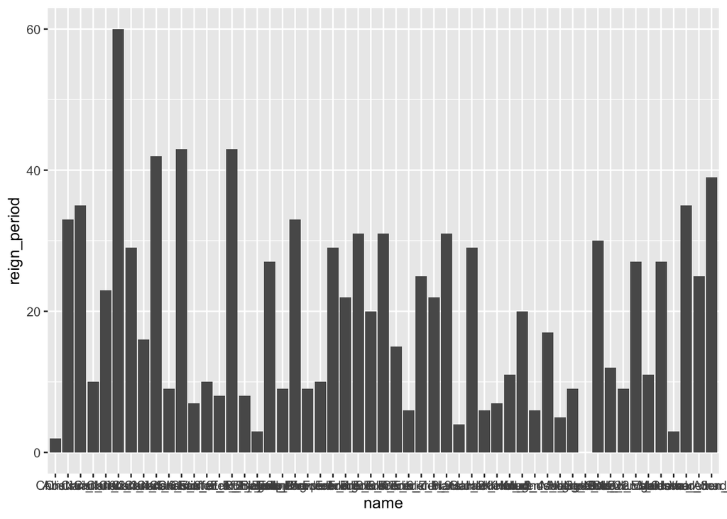

```r
ggplot(data = monarchs,
       aes(x = name,
           y = reign_period)) +
  geom_bar(stat = "identity")
```

#Second Try

This chart is showing what I told it to do, but it is very cramped, which is why I want to make another chart which is more readable and easy on the eye. That why I added the theme and choose to make the angle of the names on the x axis 45 degrees to make it more readable.

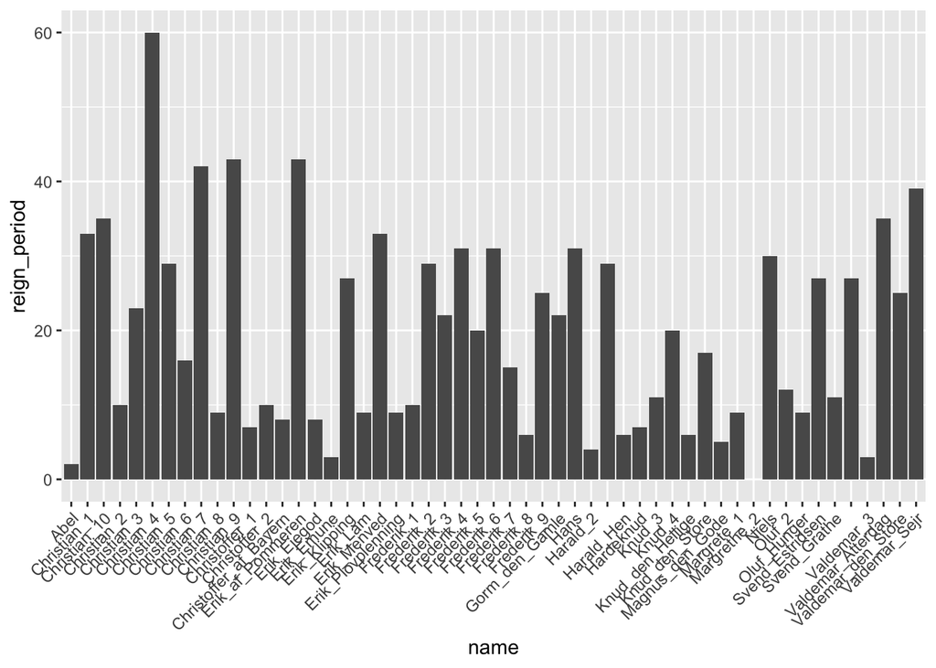

```r
ggplot(data = monarchs,
       aes(x = name,
           y = reign_period)) +
  geom_bar(stat = "identity") +
  theme(axis.text.x = element_text(angle = 45, hjust = 1))
```

#Third try

My second try still looks cramped, but it’s better. Therefore I wanted to make the last try with just the monarchs who have reigned for the longest period. Here I made another dataframe called “top_monarchs” where I choose the ones who reign the longest. Afterwards I made a new chart only with the top_monarchs dataframe and still chose to angle the names on the x axis because it made it more readable.

```r
library(dplyr)

top_monarchs <- monarchs %>%
  arrange(desc(reign_period)) %>%
  top_n(n = 10)
```

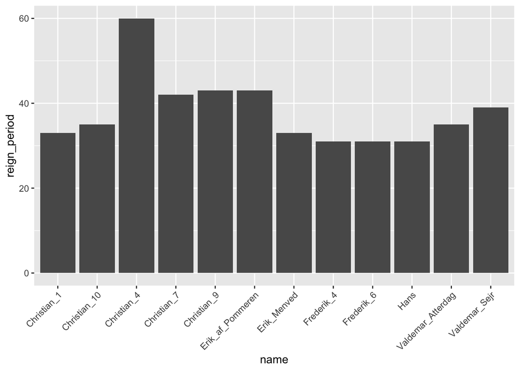

```r
ggplot(data = top_monarchs,
       aes(x = name,
           y = reign_period)) +
  geom_bar(stat = "identity") +
  theme(axis.text.x = element_text(angle = 45, hjust = 1))
```